# Optimization Project

## Introduction

The main purpose of this work is to compare linear regression methods (Least Squares, Ridge and Lasso) as solutions to the bias-variance trade-off problem. The database on which we will focus is a numerical database for superconducting materials, available here : https://archive.ics.uci.edu/ml/datasets/Superconductivty+Data#.

A zero electrical resistance and expulsion of magnetic flux fields can be observed when a superconductor is cooled below its critical temperature. It could be interesting to use multiple regression to explain the critical temperature of a superconductor by some of its characteristics (number of elements, atomic mass, density, ...).

I chose this dataset for two main reasons. First, I do not have any relevant datasets within my compagny that could be suitable for this homework. Secondly, this dataset has been uploaded quite recently (2018-10-12). So there's no online analysis available yet, that could have influenced my work.

```python
import pandas as pd
import matplotlib.pyplot as plt
import seaborn as sns
import numpy as np
import math as m
import pandas_profiling as pp
from scipy.stats import norm
from scipy import stats
from sklearn import datasets, linear_model
from sklearn.metrics import mean_squared_error, r2_score, mean_absolute_error
from sklearn.model_selection import train_test_split
from sklearn.linear_model import Ridge, Lasso, RidgeCV, LassoCV
%matplotlib inline
```

We first perform the dataset loading.

```python
data = pd.read_csv('../Optimisation/train.csv')
```

## Data Exploration

This dataset includes 21263 instances and 82 features. The feature to predict is in the 82nd column (critical temperature).

```python
[n,p] = data.shape
[n,p]
```

```
[21263, 82]
```

We can have a quick overview of the data. All the features are numerical and well formatted.

```python
print(data.head())
```

```
   number_of_elements  mean_atomic_mass  wtd_mean_atomic_mass  \
0                   4         88.944468             57.862692
1                   5         92.729214             58.518416
2                   4         88.944468             57.885242
3                   4         88.944468             57.873967
4                   4         88.944468             57.840143

   gmean_atomic_mass  wtd_gmean_atomic_mass  entropy_atomic_mass  \
0          66.361592              36.116612             1.181795
1          73.132787              36.396602             1.449309
2          66.361592              36.122509             1.181795
3          66.361592              36.119560             1.181795
4          66.361592              36.110716             1.181795

   wtd_entropy_atomic_mass  range_atomic_mass  wtd_range_atomic_mass  \
```

[output cut: 28 more lines]

```python
data.describe()
```

|  | number_of_elements | mean_atomic_mass | wtd_mean_atomic_mass | gmean_atomic_mass | wtd_gmean_atomic_mass | entropy_atomic_mass | wtd_entropy_atomic_mass | range_atomic_mass | wtd_range_atomic_mass | std_atomic_mass | ... | wtd_mean_Valence | gmean_Valence | wtd_gmean_Valence | entropy_Valence | wtd_entropy_Valence | range_Valence | wtd_range_Valence | std_Valence | wtd_std_Valence | critical_temp |
| --- | --- | --- | --- | --- | --- | --- | --- | --- | --- | --- | --- | --- | --- | --- | --- | --- | --- | --- | --- | --- | --- |
| count | 21263.000000 | 21263.000000 | 21263.000000 | 21263.000000 | 21263.000000 | 21263.000000 | 21263.000000 | 21263.000000 | 21263.000000 | 21263.000000 | ... | 21263.000000 | 21263.000000 | 21263.000000 | 21263.000000 | 21263.000000 | 21263.000000 | 21263.000000 | 21263.000000 | 21263.000000 | 21263.000000 |
| mean | 4.115224 | 87.557631 | 72.988310 | 71.290627 | 58.539916 | 1.165608 | 1.063884 | 115.601251 | 33.225218 | 44.391893 | ... | 3.153127 | 3.056536 | 3.055885 | 1.295682 | 1.052841 | 2.041010 | 1.483007 | 0.839342 | 0.673987 | 34.421219 |
| std | 1.439295 | 29.676497 | 33.490406 | 31.030272 | 36.651067 | 0.364930 | 0.401423 | 54.626887 | 26.967752 | 20.035430 | ... | 1.191249 | 1.046257 | 1.174815 | 0.393155 | 0.380291 | 1.242345 | 0.978176 | 0.484676 | 0.455580 | 34.254362 |
| min | 1.000000 | 6.941000 | 6.423452 | 5.320573 | 1.960849 | 0.000000 | 0.000000 | 0.000000 | 0.000000 | 0.000000 | ... | 1.000000 | 1.000000 | 1.000000 | 0.000000 | 0.000000 | 0.000000 | 0.000000 | 0.000000 | 0.000000 | 0.000210 |
| 25% | 3.000000 | 72.458076 | 52.143839 | 58.041225 | 35.248990 | 0.966676 | 0.775363 | 78.512902 | 16.824174 | 32.890369 | ... | 2.116732 | 2.279705 | 2.091251 | 1.060857 | 0.775678 | 1.000000 | 0.921454 | 0.451754 | 0.306892 | 5.365000 |
| 50% | 4.000000 | 84.922750 | 60.696571 | 66.361592 | 39.918385 | 1.199541 | 1.146783 | 122.906070 | 26.636008 | 45.123500 | ... | 2.618182 | 2.615321 | 2.434057 | 1.368922 | 1.166532 | 2.000000 | 1.063077 | 0.800000 | 0.500000 | 20.000000 |
| 75% | 5.000000 | 100.404410 | 86.103540 | 78.116681 | 73.113234 | 1.444537 | 1.359418 | 154.119320 | 38.356908 | 59.322812 | ... | 4.026201 | 3.727919 | 3.914868 | 1.589027 | 1.330801 | 3.000000 | 1.918400 | 1.200000 | 1.020436 | 63.000000 |
| max | 9.000000 | 208.980400 | 208.980400 | 208.980400 | 208.980400 | 1.983797 | 1.958203 | 207.972460 | 205.589910 | 101.019700 | ... | 7.000000 | 7.000000 | 7.000000 | 2.141963 | 1.949739 | 6.000000 | 6.992200 | 3.000000 | 3.000000 | 185.000000 |

8 rows × 82 columns

```python
np.unique(data.dtypes)
```

```
array([dtype('int64'), dtype('float64')], dtype=object)
```

Also, there is no missing value in the dataset.

```python
np.unique(data.isnull().any())
```

```
array([False])
```

We remove all the duplicate rows.

```python
data = data.drop_duplicates()
[n,p] = data.shape
[n,p]
```

```
[21197, 82]
```

Above is an overview of the *critical_temp* distribution.

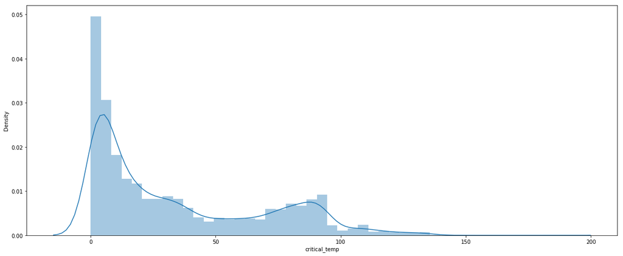

```python
plt.figure(figsize = (20,8))
sns.distplot(data['critical_temp'])
plt.ylabel("Density")
```

## Train and test split

We split the data into training data and test data.

```python
X = data.drop(["critical_temp"], axis = 1, inplace = False)
y = data['critical_temp'].copy()
```

```python
X_train,X_test,y_train,y_test=train_test_split(X,y,test_size = 0.33,random_state=324)
```

We can normalize the data. To do so, we have to use the mean and standard deviation of the train subset for both train and test subsets.

```python
m_train_X = X_train.mean(axis=0)
s_train_X = X_train.std(axis=0)
m_train_y = y_train.mean(axis=0)
s_train_y = y_train.std(axis=0)

X_train = (X_train-m_train_X)/s_train_X
X_test = (X_test-m_train_X)/s_train_X
y_train = (y_train-m_train_y)/s_train_y
y_test = (y_test-m_train_y)/s_train_y
```

We have a look at the correlation between the features. We can see that there are features highly correlated.

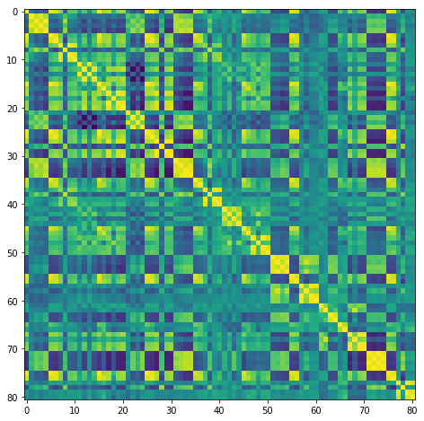

```python
plt.figure(figsize = (20,8))
C = X_train.transpose().dot(X_train)
plt.imshow(C);
```

We look at the correlation between the features and the label *y*. This correlation is very high and mainly positive.

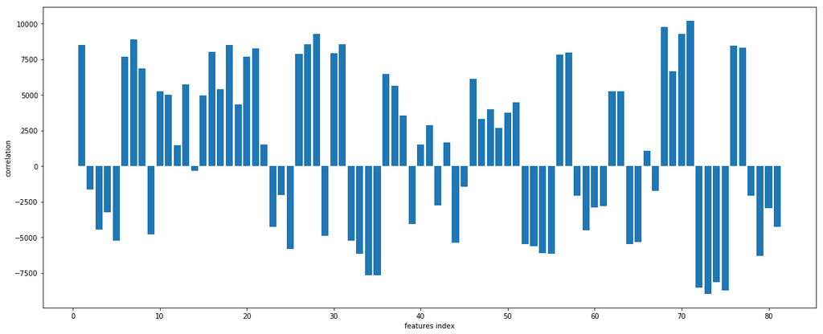

```python
plt.figure(figsize = (20,8))
plt.clf
plt.bar(np.arange(1,p),X_train.transpose().dot(y_train))
plt.axis('tight')
plt.xlabel('features index')
plt.ylabel('correlation')
```

## PCA computation

We now compute PCA ortho-basis and the feature in the PCA basis.

```python
U, s, V = np.linalg.svd(X_train)
```

Then we plot sqrt of the eigenvalues.

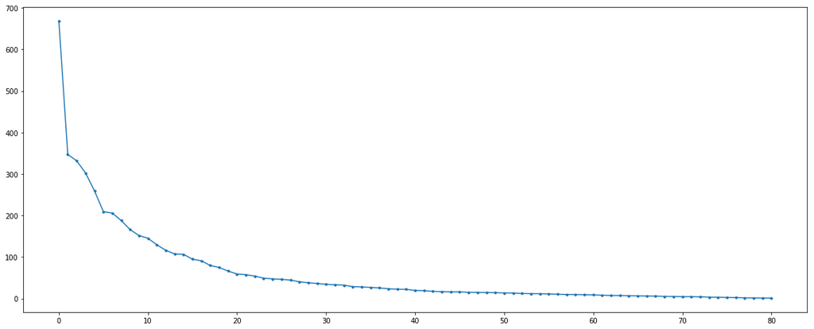

```python
plt.figure(figsize = (20,8))
X_train_r = X_train.dot( V.transpose())
plt.plot(s, '.-');
```

We check the variance explained in each column of the singular matrix and plot the related ratio. 80% of the variance is explained by the 7 first components.

```python
exp_var = (s**2) / (X.shape[0]-1)
print('Explained variance:\n', exp_var)
```

```
Explained variance:
 [2.10919066e+01 5.67742957e+00 5.18808729e+00 4.30310410e+00
 3.17189890e+00 2.06137596e+00 1.99745450e+00 1.66399607e+00
 1.29927873e+00 1.08398170e+00 9.93624308e-01 7.88103851e-01
 6.37105316e-01 5.43056244e-01 5.33855879e-01 4.22962073e-01
 3.88857565e-01 2.97980463e-01 2.63321585e-01 2.05962314e-01
 1.64113138e-01 1.54894751e-01 1.37887144e-01 1.13116986e-01
 1.05584917e-01 1.00070796e-01 9.24856331e-02 7.67622253e-02
 6.78035534e-02 6.22220662e-02 5.46403470e-02 5.15961451e-02
 4.87222739e-02 3.84009136e-02 3.68091367e-02 3.35888513e-02
 3.04768237e-02 2.62141301e-02 2.33734620e-02 2.29027986e-02
 1.76915833e-02 1.65613939e-02 1.38957108e-02 1.29706070e-02
 1.19165833e-02 1.18498712e-02 1.05923917e-02 1.02613254e-02
 9.81415221e-03 9.30314838e-03 8.37385823e-03 8.31491247e-03
 6.81333813e-03 6.49382075e-03 6.33302948e-03 5.73731730e-03
 4.89797489e-03 4.41866232e-03 4.35264750e-03 3.90352238e-03
 3.53538602e-03 3.03736678e-03 2.40703830e-03 2.38196993e-03
 2.15165215e-03 1.91006189e-03 1.73698792e-03 1.52165568e-03
 1.23125923e-03 1.12316735e-03 9.85157030e-04 8.97598894e-04
 7.90767328e-04 5.13749808e-04 4.21799509e-04 2.98137884e-04
 2.18963433e-04 1.24659617e-04 8.06357734e-05 4.94021761e-05
 3.32363750e-05]
```

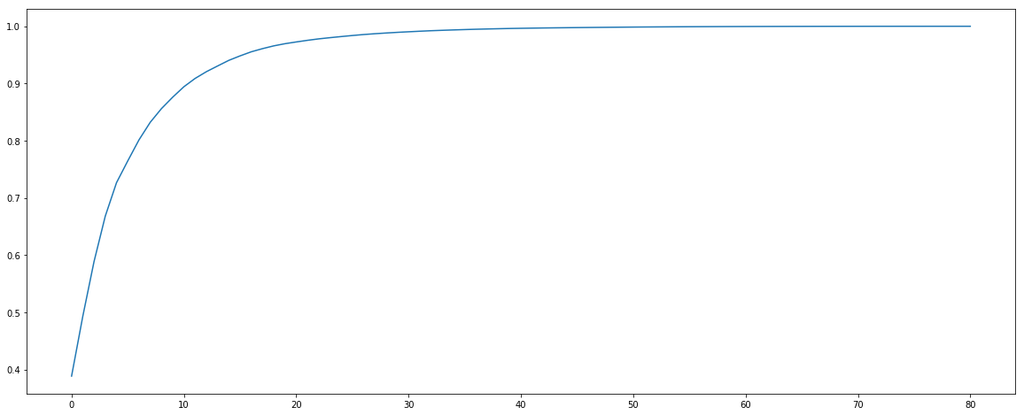

```python
plt.figure(figsize = (20,8))
plt.plot(np.cumsum(exp_var / sum(exp_var)))
```

We display the points cloud of feature vectors in 2-D PCA space.

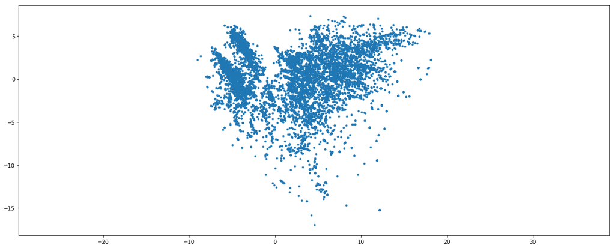

```python
plt.figure(figsize = (20,8))
plt.plot(X_train_r.iloc[:,0], X_train_r.iloc[:,1], '.')
plt.axis('equal');
```

We display a 1D plot of the function to regress along the main eigenvector axes.

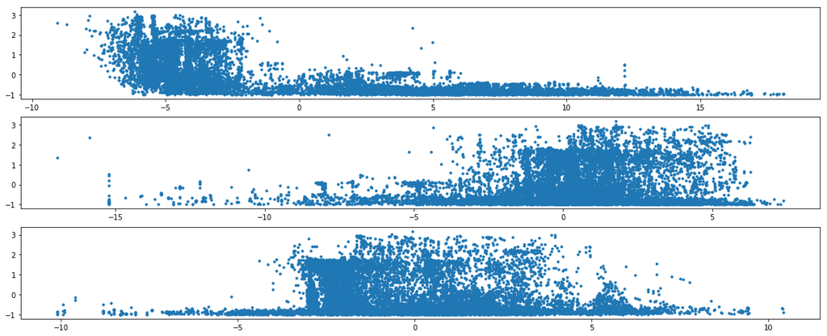

```python
plt.figure(figsize = (20,8))
plt.clf
for i in np.arange(0,3):
    plt.subplot(3,1,i+1)
    plt.plot(X_train_r.iloc[:,i], y_train, '.')
    plt.axis('tight')
```

## Linear regression

### Method seen in class

We calculate the least square solution using the following equivalent formula :

$$ w = (X^\top X)^{-1} X^\top y $$

*w* is calculated with the train subset without any kind of regularization. It is the most simple case.

```python
w = np.linalg.solve( X_train.transpose().dot(X_train), X_train.transpose().dot(y_train) )
```

Analyzing this plot is tricky due to the high number of instances. However, we can say that the model struggles to predict extreme critical temperature values.

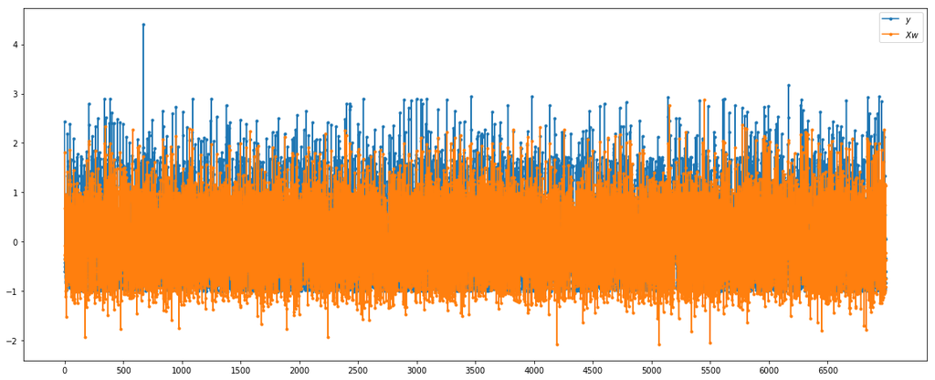

```python
plt.clf
plt.figure(figsize = (20,8))
plt.plot(y_test.values, '.-' )
plt.plot(X_test.dot(w).values, '.-' )
plt.xticks(np.arange(0, X_test.shape[0], step=500))
plt.legend(('$y$', '$X w$'));
```

We can now estimate the relative prediction error.

```python
E_LR = np.linalg.norm(X_test.dot(w)-y_test) / np.linalg.norm(y_test)
print(( 'Relative prediction error: ' + str(E_LR) ) );
```

```
Relative prediction error: 0.5112455300416369
```

### Scikit learn results

We compare these results with those obtained by using *LinearRegression()* function from **scikit-learn** library.

The relative prediction errors appear to be equal. Plus, the performance of the estimator on the test data is very similar to the performance on training data.

```python
regr = linear_model.LinearRegression()
regr.fit(X_train, y_train)
y_pred_lr = regr.predict(X_test)
E_LR_scikit = np.linalg.norm(y_pred_lr-y_test) / np.linalg.norm(y_test)
print('Relative prediction error: %.3f' % E_LR_scikit)
print('Mean squared error: %.2f' % mean_squared_error(y_test, y_pred_lr))
print('Train score : %.3f' % regr.score(X_train, y_train))
print('Test score : %.3f' % regr.score(X_test, y_test))
```

```
Relative prediction error: 0.511
Mean squared error: 0.27
Train score : 0.736
Test score : 0.739
```

## Regularization using Ridge regression

### Method seen in class

Regularization is obtained by introducing a penalty. It is often called ridge regression, and is defined as $$ \min_{w} \left\lVert{Xw-y}\right\rVert^2 + \lambda \left\lVert{w}\right\rVert^2 $$ where $\lambda>0$ is the regularization parameter.

The solution is given using the following equivalent formula $$ w = (X^\top X + \lambda \text{Id}_p )^{-1} X^\top y, $$ $$ w = X^\top ( XX^\top + \lambda \text{Id}_n)^{-1} y, $$

When $p<n$ (which is the case here), the first formula should be prefered.

Results below confirm the equivalence between both formulas.

```python
Lambda = .2*np.linalg.norm(X_train)**2;
w = np.linalg.solve( X_train.transpose().dot(X_train) + Lambda*np.eye(p-1), X_train.transpose().dot(y_train) ) #ridge estimator
u = np.linalg.solve( X_train.dot(X_train.transpose()) + Lambda*np.eye(X_train.shape[0]), y_train )
w1 = X_train.transpose().dot( u )
print( ('Error (should be 0): ' + str( np.linalg.norm(w-w1)/np.linalg.norm(w) ) ) )
```

```
Error (should be 0): 2.4424701420725577e-15
```

We display the evolution of the test error $E$ as a function of $\lambda$. This plot also indicates the optimal $\lambda$ and the associated $E$.

For the optimal lambda, **the ridge model strangely resembles the basic linear model**. Thus, the relative prediction error is similar to the one obtained with the basic LR model. This could be due to multi-colinearity issue.

```
Ridge relative prediction error: 51.153%
Optimal Lambda: 0.000001
```

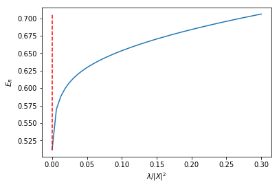

```python
q = 50
lmax = np.linalg.norm(X_train,2)**2
lambda_list = lmax*np.linspace(.3,1e-6,q)
W = np.zeros( (p-1,q) )
E_R = np.zeros( (q,1) )
for i in np.arange(0,q):
    Lambda = lambda_list[i]
    w = np.linalg.solve( X_train.transpose().dot(X_train) + Lambda*np.eye(p-1), X_train.transpose().dot(y_train) )
    W[:,i] = w.flatten() # bookkeeping
    E_R[i] = np.linalg.norm(X_test.dot(w)-y_test) / np.linalg.norm(y_test)
# find optimal lambda
i = E_R.argmin()
lambda0_R = lambda_list[i]
wRidge = W[:,i]
print('Ridge relative prediction error: %.3f' % (E_R.min()*100) + '%' )
print('Optimal Lambda: %.6f' % (lambda0_R/lmax))
# Display error evolution.
plt.clf
plt.figure(figsize = (20,8))
plt.plot(lambda_list/lmax, E_R)
plt.plot( [lambda0_R/lmax,lambda0_R/lmax], [E_R.min(), E_R.max()], 'r--')
plt.axis('tight')
plt.xlabel('$\lambda/|X|^2$')
plt.ylabel('$E_R$')
```

We take a look at the magnitude of the coefficients obtained for the optimal $\lambda\$. We see that only 3 features coefficients are very close to 0 after the ridge regularization process.

```
Number of features close to zero : 3
```

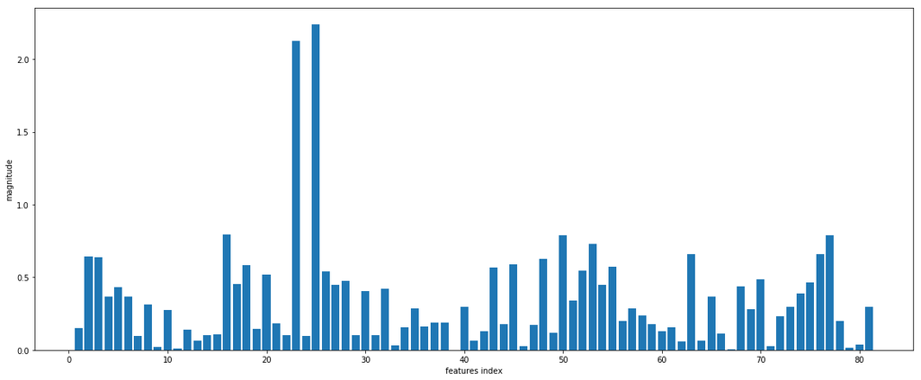

```python
plt.figure(figsize = (20,8))
plt.bar(np.arange(1,p),abs(wRidge))
print('Number of features close to zero : ' + str(sum((abs(wRidge) < 0.01))))
plt.xlabel('features index')
plt.ylabel('magnitude')
```

We confirm this conclusion by looking at the solution path of each feature.

```
No handles with labels found to put in legend.
```

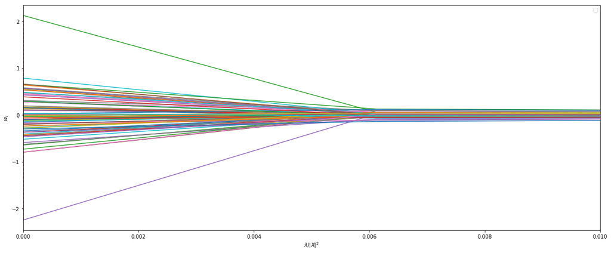

```python
plt.clf
plt.figure(figsize = (20,8))
for i in np.arange(0,p-1):
    plt.plot(lambda_list/lmax, W[i,:])
plt.plot([lambda0_R/lmax,lambda0_R/lmax], [W.flatten().min(), W.flatten().max()], 'r--')
plt.axis('tight')
plt.xlabel('$\lambda/|X|^2$')
plt.ylabel('$w_i$')
plt.xlim(0,0.01)
plt.legend()
```

### Scikit learn results

We use *Ridge()* and *RidgeCV()* functions from **scikitlearn** library in order to compare the results and metrics for different $\lambda$ values.

Here, we calculate the optimal $\lambda$ using *RidgeCV* function. Its value is equal to the one obtained with the custom method seen in class. Same observation for the relative prediction error.

When $\lambda$ is increasing, ridge regression shrinks the coefficients. Howether, an underfitting issue appears as train and test scores decrease.

```python
#ridge optimal lambda estimated by CV, folds nb = 5
Ridgeopt = RidgeCV(alphas=[0.000001, 0.00001, 0.0001, 0.0003, 0.0006, 0.001, 0.003, 0.006, 0.01, 0.03, 0.06, 0.1, 0.3, 0.6, 1], cv=5, normalize = True)
Ridgeopt.fit(X_train,y_train)
y_pred_Ridgeopt = Ridgeopt.predict(X_test)
E_Ridge_opt_scikit = np.linalg.norm(y_pred_Ridgeopt-y_test) / np.linalg.norm(y_test)
print('Optimal lambda: ' + str(Ridgeopt.alpha_))
print('Relative prediction error: %.3f' % E_Ridge_opt_scikit)
print('Mean squared error: %.2f' % mean_squared_error(y_test, y_pred_Ridgeopt))
print('Train score : %.3f' % Ridgeopt.score(X_train, y_train))
print('Test score : %.3f' % Ridgeopt.score(X_test, y_test))
```

```
Optimal lambda: 1e-06
Relative prediction error: 0.511
Mean squared error: 0.27
Train score : 0.736
Test score : 0.739
```

```python
# ridge lambda = 0.01
Ridge001 = Ridge(alpha=0.01, normalize = True)
Ridge001.fit(X_train,y_train)
y_pred_Ridge001 = Ridge001.predict(X_test)
E_Ridge_001_scikit = np.linalg.norm(y_pred_Ridge001-y_test) / np.linalg.norm(y_test)
print('Relative prediction error: %.3f' % E_Ridge_001_scikit)
print('Mean squared error: %.2f' % mean_squared_error(y_test, y_pred_Ridge001))
print('Train score : %.3f' % Ridge001.score(X_train, y_train))
print('Test score : %.3f' % Ridge001.score(X_test, y_test))
```

```
Relative prediction error: 0.528
Mean squared error: 0.28
Train score : 0.718
Test score : 0.721
```

```python
# ridge lambda = 0.1
Ridge01 = Ridge(alpha=0.1, normalize = True)
Ridge01.fit(X_train,y_train)
y_pred_Ridge01 = Ridge01.predict(X_test)
E_Ridge_01_scikit = np.linalg.norm(y_pred_Ridge01-y_test) / np.linalg.norm(y_test)
print('Relative prediction error: %.3f' % E_Ridge_01_scikit)
print('Mean squared error: %.2f' % mean_squared_error(y_test, y_pred_Ridge01))
print('Train score : %.3f' % Ridge01.score(X_train, y_train))
print('Test score : %.3f' % Ridge01.score(X_test, y_test))
```

```
Relative prediction error: 0.556
Mean squared error: 0.32
Train score : 0.687
Test score : 0.691
```

```python
# ridge lambda = 10
Ridge10 = Ridge(alpha=10, normalize = True)
Ridge10.fit(X_train,y_train)
y_pred_Ridge10 = Ridge10.predict(X_test)
E_Ridge_10_scikit = np.linalg.norm(y_pred_Ridge10-y_test) / np.linalg.norm(y_test)
print('Relative prediction error: %.3f' % E_Ridge_10_scikit)
print('Mean squared error: %.2f' % mean_squared_error(y_test, y_pred_Ridge10))
print('Variance score: %.2f' % r2_score(y_test, y_pred_Ridge10)) # Explained variance score: 1 is perfect prediction
print('Train score : %.3f' % Ridge10.score(X_train, y_train))
print('Test score : %.3f' % Ridge10.score(X_test, y_test))
```

```
Relative prediction error: 0.709
Mean squared error: 0.51
Variance score: 0.50
Train score : 0.495
Test score : 0.497
```

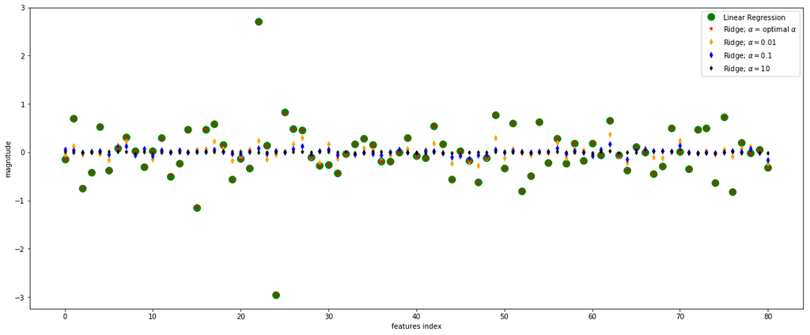

```python
plt.figure(figsize = (20,8))
plt.plot(regr.coef_,alpha=1,linestyle='none',marker='o',markersize=10,color='green',label='Linear Regression')
plt.plot(Ridgeopt.coef_,alpha=1,linestyle='none',marker='*',markersize=5,color='red',label=r'Ridge; $\alpha$ = optimal $\alpha$',zorder=7)
plt.plot(Ridge001.coef_,alpha=1,linestyle='none',marker='d',markersize=5,color='orange',label=r'Ridge; $\alpha = 0.01$')
plt.plot(Ridge01.coef_,alpha=1,linestyle='none',marker='d',markersize=5,color='blue',label=r'Ridge; $\alpha = 0.1$')
plt.plot(Ridge10.coef_,alpha=1,linestyle='none',marker='d',markersize=4,color='black',label=r'Ridge; $\alpha = 10$')
plt.legend()
plt.xlabel('features index')
plt.ylabel('magnitude')
```

## Regularization using Lasso regression

### Method seen in class

To perform the Lasso regression, we will use the ISTA algorithm that we've seen in class.

```python
y_train = pd.Series.to_frame(y_train)
y_test = pd.Series.to_frame(y_test)
def J(w,Lambda): return 1/2*np.linalg.norm(X_train.dot(w).values-y_train.values)**2 + Lambda*np.linalg.norm(w,1)
```

```python
def Soft(x,s): return np.maximum( abs(x)-s, np.zeros(x.shape)  ) * np.sign(x)
```

We display the soft thresholding operator.

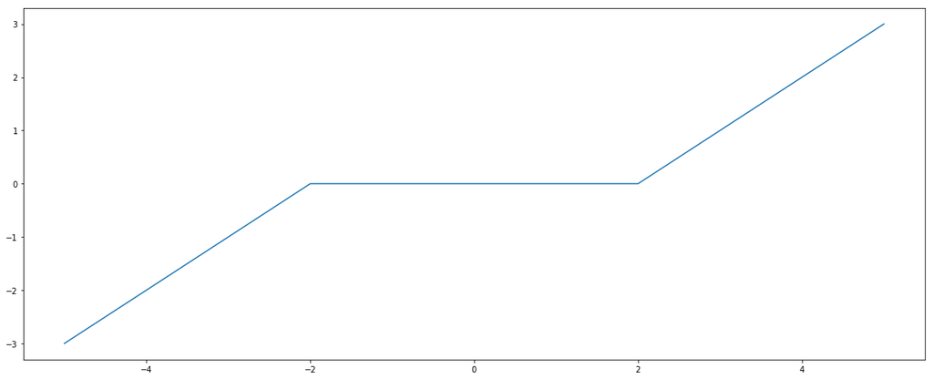

```python
t = np.linspace(-5,5,201)
plt.figure(figsize = (20,8))
plt.clf
plt.plot(t,Soft(t,2))
plt.axis('tight');
```

We define the descent step size.

```python
tau = 1.5/np.linalg.norm(X_train,2)**2
```

We arbitraly choose a regularization parameter λ for the initialization step. λ has to be lower than λmax.

```python
lmax = abs( X_train.transpose().dot(y_train) ).max()
Lambda = lmax / 10
```

```python
w = np.zeros((p-1,1))
```

```python
C = X_train.transpose().dot(X_train)
u = X_train.transpose().dot(y_train)
def ISTA(w,Lambda,tau): return Soft( w -tau*( C.dot(w).values-u.values), (Lambda*tau).values ) #ista fait le softthreesholding de la descente de gradient en lambda*tau qui est le seuil
w = ISTA(w,Lambda,tau)
```

We can now implement the ISTA algorithm.

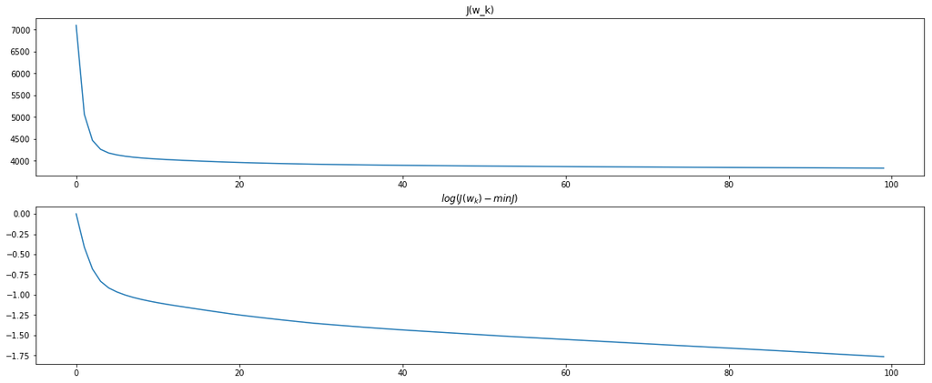

```python
niter = 400
Jlist = np.zeros((niter,1))
w = np.zeros((p-1,1))
for i in np.arange(0,niter):
    Jlist[i] = J(w,Lambda)
    w = ISTA(w,Lambda,tau)
ndisp = int(niter/4)
plt.clf
plt.figure(figsize = (20,8))
plt.subplot(2,1,1)
plt.plot(Jlist[0:ndisp])
plt.axis('tight')
plt.title('J(w_k)')
plt.subplot(2,1,2)
e = np.log10( Jlist[0:ndisp]-Jlist.min() +1e-20)
plt.plot(e-e[0])
plt.axis('tight')
plt.title('$log(J(w_k)-min J)$')
```

As we did for the Ridge regression part, we display the evolution of the test error $E$ as a function of $\lambda$.

```python
q = 100
lambda_list = (lmax.values)*np.linspace(.3,1e-6,q)
W = np.zeros( (p-1,q) )
E_L = np.zeros( (q,1) )
w1 = np.zeros((p-1,1))
niter = 500
for iq in np.arange(0,q):
    Lambda1= pd.Series(lambda_list[iq])
    # ISTA #
    for i in np.arange(0,niter):
        w1 = ISTA(w1,Lambda1,tau)
    W[:,iq] = w1.flatten() # bookkeeping
    E_L[iq] = np.linalg.norm(X_test.dot(w1)-y_test.values)/np.linalg.norm(y_test.values)
```

```
Lasso: relative prediction error: 53.256%
Optimal Lambda: 0.000001
```

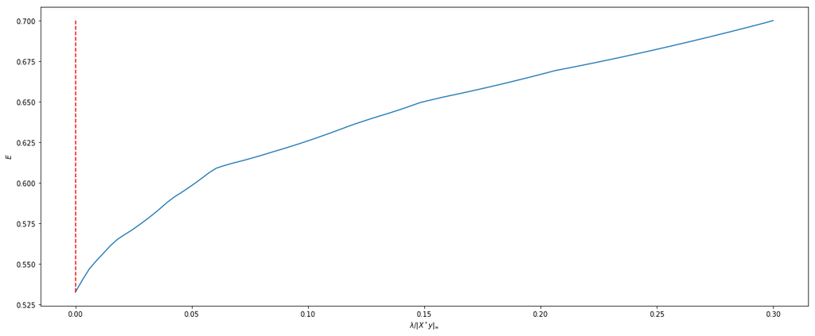

```python
# find optimal Lambda
i = E_L.argmin()
lambda0_L = lambda_list[i]
wSparse = W[:,i]
print('Lasso: relative prediction error: %.3f' % (E_L.min()*100) + '%' )
print('Optimal Lambda: %.6f' % (lambda0_L/lmax.values))
# Display error evolution.
plt.clf
plt.figure(figsize = (20,8))
plt.plot(lambda_list/lmax.values, E_L)
plt.plot([lambda0_L/lmax.values,lambda0_L/lmax.values], [E_L.min(),E_L.max()], 'r--')
plt.axis('tight')
plt.xlabel('$\lambda/|X^* y|_\infty$')
plt.ylabel('$E$')
```

The comparison of the magnitude of the coefficients reveals that the penalization has been higher with the Lasso method.

As we can see below, there are 13 more coefficients values close to zero in the Lasso model.

However, **it seems strange that, for the optimal *$\lambda$*, there are no redundant variable that Lasso method wants to put to zero**.

```
Number of features coefficients < 0.01 (LASSO) : 16
Number of features coefficients < 0.01 (RIDGE) : 3

Number of features coefficients = 0 (LASSO) : 0
Number of features coefficients = 0 (RIDGE) : 0
```

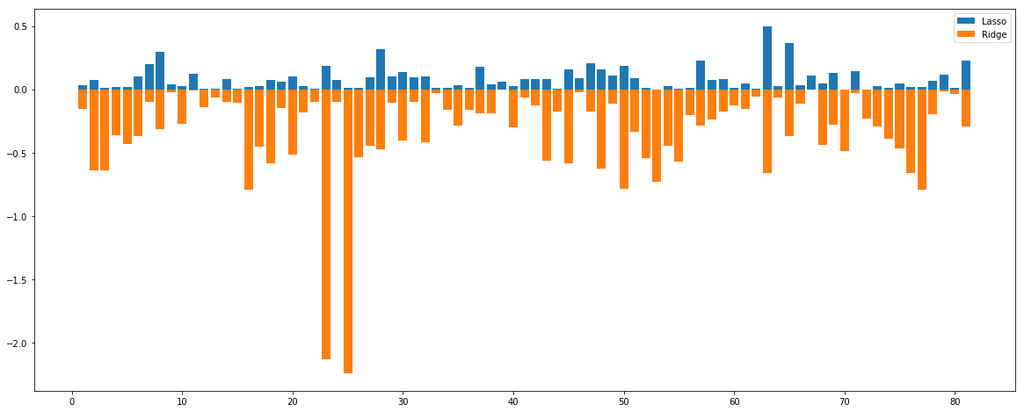

```python
plt.figure(figsize = (20,8))
plt.clf
plt.bar(np.arange(1,p), abs(wSparse))
plt.bar(np.arange(1,p), -abs(wRidge))
plt.legend(('Lasso', 'Ridge'))
print('Number of features coefficients < 0.01 (LASSO) : ' + str(sum((abs(wSparse) < 0.01))))
print('Number of features coefficients < 0.01 (RIDGE) : ' + str(sum((abs(wRidge) < 0.01))) + '\n')
print('Number of features coefficients = 0 (LASSO) : ' + str(sum((abs(wSparse) == 0))))
print('Number of features coefficients = 0 (RIDGE) : ' + str(sum((abs(wRidge) == 0))))
```

```
No handles with labels found to put in legend.
```

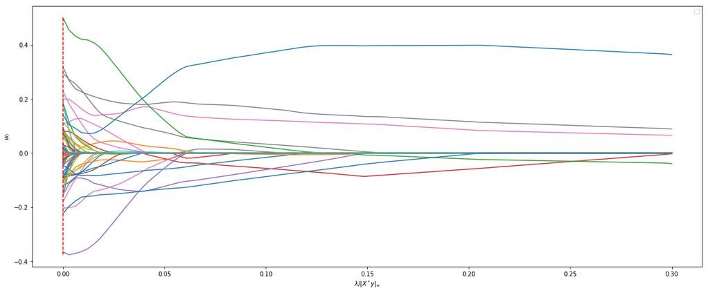

```python
plt.figure(figsize = (20,8))
plt.clf
for i in np.arange(0,p-1):
    plt.plot(lambda_list/lmax.values, W[i,:])
plt.plot( [lambda0_L/lmax.values,lambda0_L/lmax.values], [W.flatten().min(),W.flatten().max()], 'r--')
plt.axis('tight')
plt.xlabel('$\lambda/|X^* y|_\infty$')
plt.ylabel('$w_i$')
plt.legend()
```

### Scikit learn results

We use *Lasso()* and *LassoCV* function from **scikit-learn** library in order to compare the results and metrics for different $\lambda$ values.

Here, we calculate the optimal $\lambda$ using *LassoCV* function. Its value is equal to the one obtained with the Ridge method. However, we have a convergence issue pointed out by a warning message. **The optimal $\lambda$ value seems clearly unstable**.

When $\lambda$ is increasing, Lasso regression not only shrinks the coefficients more significantly than the Ridge regression, but also put features coefficient to zero. As a consequence, the underfitting issue appears faster than for the Ridge method.

```python
X_train = X_train.values
y_train = y_train.values
X_test = X_test.values
y_test = y_test.values
```

```python
# Lasso lambda optimal
import warnings
warnings.filterwarnings('ignore') #hiding the convergence issue ...
Lasso_opt = LassoCV(alphas=[0.000001, 0.00001, 0.0001, 0.0003, 0.0006, 0.001, 0.003, 0.006, 0.01, 0.03, 0.06, 0.1, 0.3, 0.6, 1], cv=5, normalize = True)
Lasso_opt.fit(X_train,y_train)
y_pred_Lasso_opt = Lasso_opt.predict(X_test)
E_Lasso_opt_scikit = np.linalg.norm(y_pred_Lasso_opt-y_test) / np.linalg.norm(y_test)
Coeff_rm_opt = sum(Lasso_opt.coef_== 0)
print('Optimal lambda: ' + str(Lasso_opt.alpha_))
print('Relative prediction error: %.3f' % E_Lasso_opt_scikit)
print('Mean squared error: %.2f' % mean_squared_error(y_test, y_pred_Lasso_opt))
print('Train score : %.3f' % Lasso_opt.score(X_train, y_train))
print('Test score : %.3f' % Lasso_opt.score(X_test, y_test))
print('Number of coef removed : ' + str(Coeff_rm_opt))
warnings.filterwarnings('default')
```

```
Optimal lambda: 1e-06
Relative prediction error: 110.207
Mean squared error: 0.27
Train score : 0.733
Test score : 0.735
Number of coef removed : 0
```

```python
# Lasso lambda 0.01
Lasso_001 = Lasso(alpha = 0.01)
Lasso_001.fit(X_train,y_train)
y_pred_Lasso_001 = Lasso_001.predict(X_test)
E_Lasso_001_scikit = np.linalg.norm(y_pred_Lasso_001-y_test) / np.linalg.norm(y_test)
Coeff_rm_001 = sum(Lasso_001.coef_== 0)
print('Relative prediction error: %.3f' % E_Lasso_001_scikit)
print('Mean squared error: %.2f' % mean_squared_error(y_test, y_pred_Lasso_001))
print('Train score : %.3f' % Lasso_001.score(X_train, y_train))
print('Test score : %.3f' % Lasso_001.score(X_test, y_test))
print('Number of coef removed : ' + str(Coeff_rm_001))
```

```
Relative prediction error: 107.122
Mean squared error: 0.32
Train score : 0.683
Test score : 0.688
Number of coef removed : 57
```

```python
# Lasso lambda 0.1
Lasso_01 = Lasso(alpha = 0.1)
Lasso_01.fit(X_train,y_train)
y_pred_Lasso_01 = Lasso_01.predict(X_test)
E_Lasso_01_scikit = np.linalg.norm(y_pred_Lasso_01-y_test) / np.linalg.norm(y_test)
Coeff_rm_01 = sum(Lasso_01.coef_== 0)
print('Relative prediction error: %.3f' % E_Lasso_01_scikit)
print('Mean squared error: %.2f' % mean_squared_error(y_test, y_pred_Lasso_01))
print('Train score : %.3f' % Lasso_01.score(X_train, y_train))
print('Test score : %.3f' % Lasso_01.score(X_test, y_test))
print('Number of coef removed : ' + str(Coeff_rm_01))
```

```
Relative prediction error: 99.548
Mean squared error: 0.42
Train score : 0.581
Test score : 0.584
Number of coef removed : 73
```

```python
# Lasso lambda 10
Lasso_10 = Lasso(alpha = 10)
Lasso_10.fit(X_train,y_train)
y_pred_Lasso_10 = Lasso_10.predict(X_test)
E_Lasso_10_scikit = np.linalg.norm(y_pred_Lasso_10-y_test) / np.linalg.norm(y_test)
Coeff_rm_10 = sum(Lasso_10.coef_== 0)
print('Relative prediction error: %.3f' % E_Lasso_10_scikit)
print('Mean squared error: %.2f' % mean_squared_error(y_test, y_pred_Lasso_10))
print('Train score : %.3f' % Lasso_10.score(X_train, y_train))
print('Test score : %.3f' % Lasso_10.score(X_test, y_test))
print('Number of coef removed : ' + str(Coeff_rm_10))
```

```
Relative prediction error: 83.642
Mean squared error: 1.02
Train score : 0.000
Test score : -0.000
Number of coef removed : 81
```

[figure not shown]

```python
plt.figure(figsize = (20,8))
plt.plot(regr.coef_,alpha=1,linestyle='none',marker='o',markersize=10,color='green',label='Linear Regression')
plt.plot(Lasso_opt.coef_,alpha=1,linestyle='none',marker='*',markersize=5,color='red',label=r'Lasso; $\alpha$ = optimal $\alpha$',zorder=7) # zorder for ordering the markers
plt.plot(Lasso_001.coef_,alpha=1,linestyle='none',marker='d',markersize=5,color='orange',label=r'Lasso; $\alpha = 0.01$')
plt.plot(Lasso_01.coef_,alpha=1,linestyle='none',marker='d',markersize=5,color='blue',label=r'Lasso; $\alpha = 0.1$')
plt.plot(Lasso_10.coef_,alpha=1,linestyle='none',marker='d',markersize=4,color='black',label=r'Ridge; $\alpha = 10$') # alpha here is for transparency
plt.legend()
plt.xlabel('features index')
plt.ylabel('magnitude')
```

## Conclusion

As a conclusion, despite the estimation of the optimal *$\lambda$* issue, using Ridge or Lasso regressions as an alternative to the basic linear model could be interesting when :

- we want to simplify the model by only shrinking the features coefficients without losing to much performance (RIDGE),
- we want a simple and interpretable model by performing features selection (LASSO).

The calculation of the optimal *$\lambda$* was actually very tricky. Having tried different ranges of *$\lambda$* for both methods, the smallest *$\lambda$* value was constently the best output to choose as optimal *$\lambda$*, pointing out a convergence issue.

This issue could be due to the presence of a very high colinearity in the predictors used to build the response, that probably makes the optimal *$\lambda$* value unstable. Indeed, the variance of the coefficients may have been inflated due to the nature of the features, leading to this *$\lambda$* issue.

As removing duplicate rows was the only preprocessing I performed on the data, improving the preprocessing step or knowing better the nature of the data might have been profitable for this study. On the other side, this issue has been a good thing as it forces me to go deeply in understanding these methods and limits.

## Introduction

The main purpose of this work is to compare linear regression methods (Least Squares, Ridge and Lasso) as solutions to the bias-variance trade-off problem. The database on which we will focus is a numerical database for superconducting materials, available here : https://archive.ics.uci.edu/ml/datasets/Superconductivty+Data#.

A zero electrical resistance and expulsion of magnetic flux fields can be observed when a superconductor is cooled below its critical temperature. It could be interesting to use multiple regression to explain the critical temperature of a superconductor by some of its characteristics (number of elements, atomic mass, density, ...).

I chose this dataset for two main reasons. First, I do not have any relevant datasets within my compagny that could be suitable for this homework. Secondly, this dataset has been uploaded quite recently (2018-10-12). So there's no online analysis available yet, that could have influenced my work.

```python
import pandas as pd
import matplotlib.pyplot as plt
import seaborn as sns
import numpy as np
import math as m
import pandas_profiling as pp
from scipy.stats import norm
from scipy import stats
from sklearn import datasets, linear_model
from sklearn.metrics import mean_squared_error, r2_score, mean_absolute_error
from sklearn.model_selection import train_test_split
from sklearn.linear_model import Ridge, Lasso, RidgeCV, LassoCV
%matplotlib inline
```

We first perform the dataset loading.

```python
data = pd.read_csv('../Optimisation/train.csv')
```

## Data Exploration

This dataset includes 21263 instances and 82 features. The feature to predict is in the 82nd column (critical temperature).

```python
[n,p] = data.shape
[n,p]
```

```
[21263, 82]
```

We can have a quick overview of the data. All the features are numerical and well formatted.

```python
print(data.head())
```

```
   number_of_elements  mean_atomic_mass  wtd_mean_atomic_mass  \
0                   4         88.944468             57.862692
1                   5         92.729214             58.518416
2                   4         88.944468             57.885242
3                   4         88.944468             57.873967
4                   4         88.944468             57.840143

   gmean_atomic_mass  wtd_gmean_atomic_mass  entropy_atomic_mass  \
0          66.361592              36.116612             1.181795
1          73.132787              36.396602             1.449309
2          66.361592              36.122509             1.181795
3          66.361592              36.119560             1.181795
4          66.361592              36.110716             1.181795

   wtd_entropy_atomic_mass  range_atomic_mass  wtd_range_atomic_mass  \
```

[output cut: 28 more lines]

```python
data.describe()
```

|  | number_of_elements | mean_atomic_mass | wtd_mean_atomic_mass | gmean_atomic_mass | wtd_gmean_atomic_mass | entropy_atomic_mass | wtd_entropy_atomic_mass | range_atomic_mass | wtd_range_atomic_mass | std_atomic_mass | ... | wtd_mean_Valence | gmean_Valence | wtd_gmean_Valence | entropy_Valence | wtd_entropy_Valence | range_Valence | wtd_range_Valence | std_Valence | wtd_std_Valence | critical_temp |
| --- | --- | --- | --- | --- | --- | --- | --- | --- | --- | --- | --- | --- | --- | --- | --- | --- | --- | --- | --- | --- | --- |
| count | 21263.000000 | 21263.000000 | 21263.000000 | 21263.000000 | 21263.000000 | 21263.000000 | 21263.000000 | 21263.000000 | 21263.000000 | 21263.000000 | ... | 21263.000000 | 21263.000000 | 21263.000000 | 21263.000000 | 21263.000000 | 21263.000000 | 21263.000000 | 21263.000000 | 21263.000000 | 21263.000000 |
| mean | 4.115224 | 87.557631 | 72.988310 | 71.290627 | 58.539916 | 1.165608 | 1.063884 | 115.601251 | 33.225218 | 44.391893 | ... | 3.153127 | 3.056536 | 3.055885 | 1.295682 | 1.052841 | 2.041010 | 1.483007 | 0.839342 | 0.673987 | 34.421219 |
| std | 1.439295 | 29.676497 | 33.490406 | 31.030272 | 36.651067 | 0.364930 | 0.401423 | 54.626887 | 26.967752 | 20.035430 | ... | 1.191249 | 1.046257 | 1.174815 | 0.393155 | 0.380291 | 1.242345 | 0.978176 | 0.484676 | 0.455580 | 34.254362 |
| min | 1.000000 | 6.941000 | 6.423452 | 5.320573 | 1.960849 | 0.000000 | 0.000000 | 0.000000 | 0.000000 | 0.000000 | ... | 1.000000 | 1.000000 | 1.000000 | 0.000000 | 0.000000 | 0.000000 | 0.000000 | 0.000000 | 0.000000 | 0.000210 |
| 25% | 3.000000 | 72.458076 | 52.143839 | 58.041225 | 35.248990 | 0.966676 | 0.775363 | 78.512902 | 16.824174 | 32.890369 | ... | 2.116732 | 2.279705 | 2.091251 | 1.060857 | 0.775678 | 1.000000 | 0.921454 | 0.451754 | 0.306892 | 5.365000 |
| 50% | 4.000000 | 84.922750 | 60.696571 | 66.361592 | 39.918385 | 1.199541 | 1.146783 | 122.906070 | 26.636008 | 45.123500 | ... | 2.618182 | 2.615321 | 2.434057 | 1.368922 | 1.166532 | 2.000000 | 1.063077 | 0.800000 | 0.500000 | 20.000000 |
| 75% | 5.000000 | 100.404410 | 86.103540 | 78.116681 | 73.113234 | 1.444537 | 1.359418 | 154.119320 | 38.356908 | 59.322812 | ... | 4.026201 | 3.727919 | 3.914868 | 1.589027 | 1.330801 | 3.000000 | 1.918400 | 1.200000 | 1.020436 | 63.000000 |
| max | 9.000000 | 208.980400 | 208.980400 | 208.980400 | 208.980400 | 1.983797 | 1.958203 | 207.972460 | 205.589910 | 101.019700 | ... | 7.000000 | 7.000000 | 7.000000 | 2.141963 | 1.949739 | 6.000000 | 6.992200 | 3.000000 | 3.000000 | 185.000000 |

8 rows × 82 columns

```python
np.unique(data.dtypes)
```

```
array([dtype('int64'), dtype('float64')], dtype=object)
```

Also, there is no missing value in the dataset.

```python
np.unique(data.isnull().any())
```

```
array([False])
```

We remove all the duplicate rows.

```python
data = data.drop_duplicates()
[n,p] = data.shape
[n,p]
```

```
[21197, 82]
```

Above is an overview of the *critical_temp* distribution.

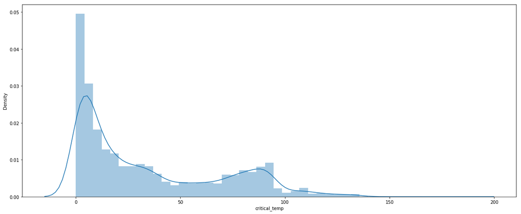

```python
plt.figure(figsize = (20,8))
sns.distplot(data['critical_temp'])
plt.ylabel("Density")
```

## Train and test split

We split the data into training data and test data.

```python
X = data.drop(["critical_temp"], axis = 1, inplace = False)
y = data['critical_temp'].copy()
```

```python
X_train,X_test,y_train,y_test=train_test_split(X,y,test_size = 0.33,random_state=324)
```

We can normalize the data. To do so, we have to use the mean and standard deviation of the train subset for both train and test subsets.

```python
m_train_X = X_train.mean(axis=0)
s_train_X = X_train.std(axis=0)
m_train_y = y_train.mean(axis=0)
s_train_y = y_train.std(axis=0)

X_train = (X_train-m_train_X)/s_train_X
X_test = (X_test-m_train_X)/s_train_X
y_train = (y_train-m_train_y)/s_train_y
y_test = (y_test-m_train_y)/s_train_y
```

We have a look at the correlation between the features. We can see that there are features highly correlated.

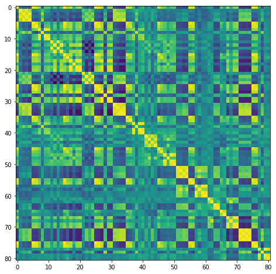

```python
plt.figure(figsize = (20,8))
C = X_train.transpose().dot(X_train)
plt.imshow(C);
```

We look at the correlation between the features and the label *y*. This correlation is very high and mainly positive.

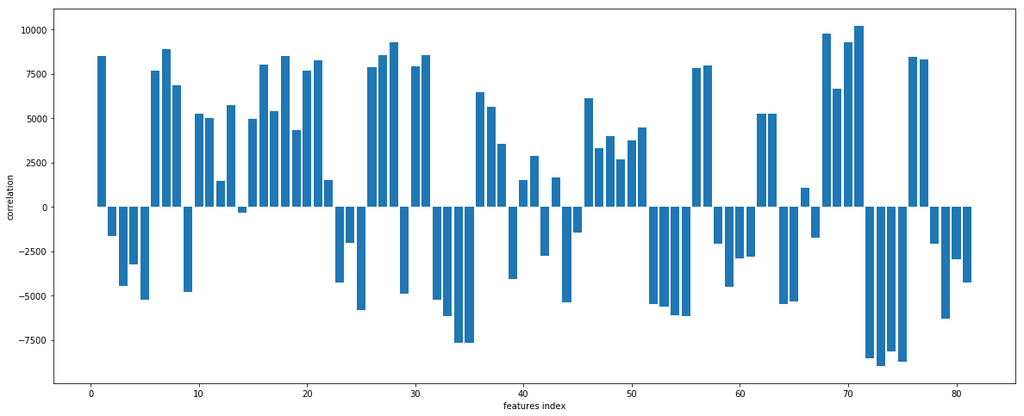

```python
plt.figure(figsize = (20,8))
plt.clf
plt.bar(np.arange(1,p),X_train.transpose().dot(y_train))
plt.axis('tight')
plt.xlabel('features index')
plt.ylabel('correlation')
```

## PCA computation

We now compute PCA ortho-basis and the feature in the PCA basis.

```python
U, s, V = np.linalg.svd(X_train)
```

Then we plot sqrt of the eigenvalues.

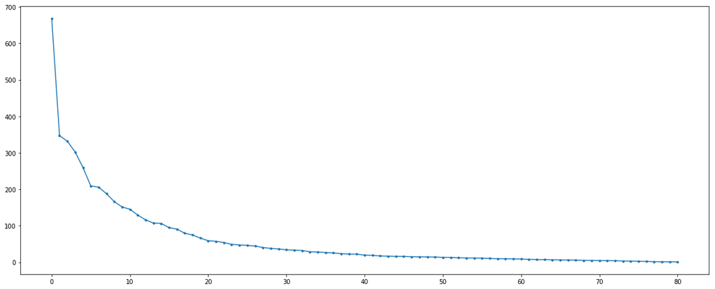

```python
plt.figure(figsize = (20,8))
X_train_r = X_train.dot( V.transpose())
plt.plot(s, '.-');
```

We check the variance explained in each column of the singular matrix and plot the related ratio. 80% of the variance is explained by the 7 first components.

```python
exp_var = (s**2) / (X.shape[0]-1)
print('Explained variance:\n', exp_var)
```

```
Explained variance:
 [2.10919066e+01 5.67742957e+00 5.18808729e+00 4.30310410e+00
 3.17189890e+00 2.06137596e+00 1.99745450e+00 1.66399607e+00
 1.29927873e+00 1.08398170e+00 9.93624308e-01 7.88103851e-01
 6.37105316e-01 5.43056244e-01 5.33855879e-01 4.22962073e-01
 3.88857565e-01 2.97980463e-01 2.63321585e-01 2.05962314e-01
 1.64113138e-01 1.54894751e-01 1.37887144e-01 1.13116986e-01
 1.05584917e-01 1.00070796e-01 9.24856331e-02 7.67622253e-02
 6.78035534e-02 6.22220662e-02 5.46403470e-02 5.15961451e-02
 4.87222739e-02 3.84009136e-02 3.68091367e-02 3.35888513e-02
 3.04768237e-02 2.62141301e-02 2.33734620e-02 2.29027986e-02
 1.76915833e-02 1.65613939e-02 1.38957108e-02 1.29706070e-02
 1.19165833e-02 1.18498712e-02 1.05923917e-02 1.02613254e-02
 9.81415221e-03 9.30314838e-03 8.37385823e-03 8.31491247e-03
 6.81333813e-03 6.49382075e-03 6.33302948e-03 5.73731730e-03
 4.89797489e-03 4.41866232e-03 4.35264750e-03 3.90352238e-03
 3.53538602e-03 3.03736678e-03 2.40703830e-03 2.38196993e-03
 2.15165215e-03 1.91006189e-03 1.73698792e-03 1.52165568e-03
 1.23125923e-03 1.12316735e-03 9.85157030e-04 8.97598894e-04
 7.90767328e-04 5.13749808e-04 4.21799509e-04 2.98137884e-04
 2.18963433e-04 1.24659617e-04 8.06357734e-05 4.94021761e-05
 3.32363750e-05]
```

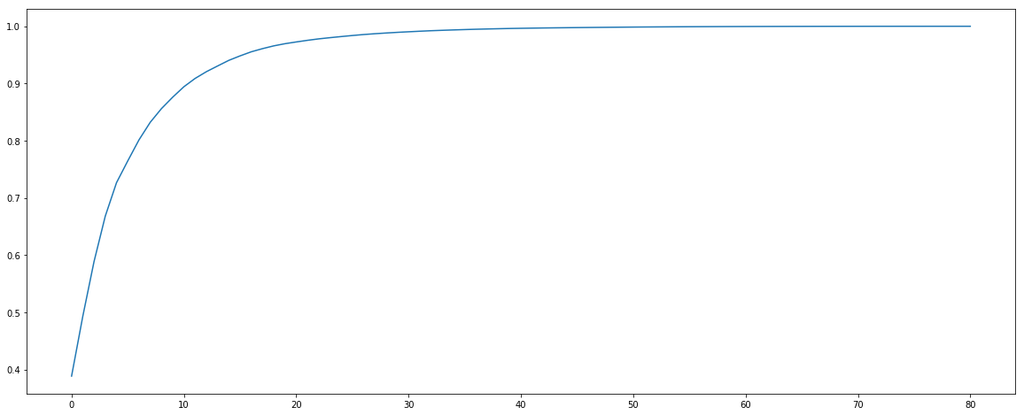

```python
plt.figure(figsize = (20,8))
plt.plot(np.cumsum(exp_var / sum(exp_var)))
```

We display the points cloud of feature vectors in 2-D PCA space.

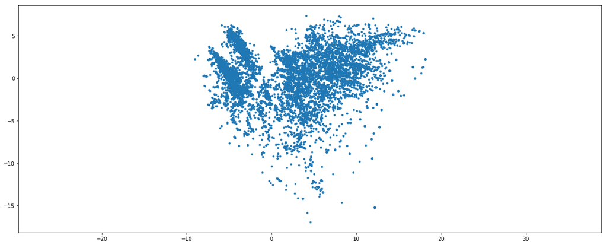

```python
plt.figure(figsize = (20,8))
plt.plot(X_train_r.iloc[:,0], X_train_r.iloc[:,1], '.')
plt.axis('equal');
```

We display a 1D plot of the function to regress along the main eigenvector axes.

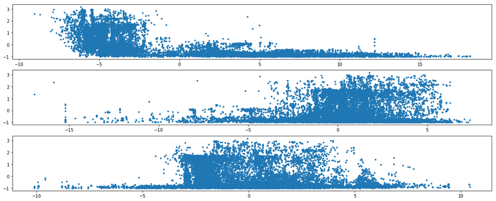

```python
plt.figure(figsize = (20,8))
plt.clf
for i in np.arange(0,3):
    plt.subplot(3,1,i+1)
    plt.plot(X_train_r.iloc[:,i], y_train, '.')
    plt.axis('tight')
```

## Linear regression

### Method seen in class

We calculate the least square solution using the following equivalent formula :

$$ w = (X^\top X)^{-1} X^\top y $$

*w* is calculated with the train subset without any kind of regularization. It is the most simple case.

```python
w = np.linalg.solve( X_train.transpose().dot(X_train), X_train.transpose().dot(y_train) )
```

Analyzing this plot is tricky due to the high number of instances. However, we can say that the model struggles to predict extreme critical temperature values.

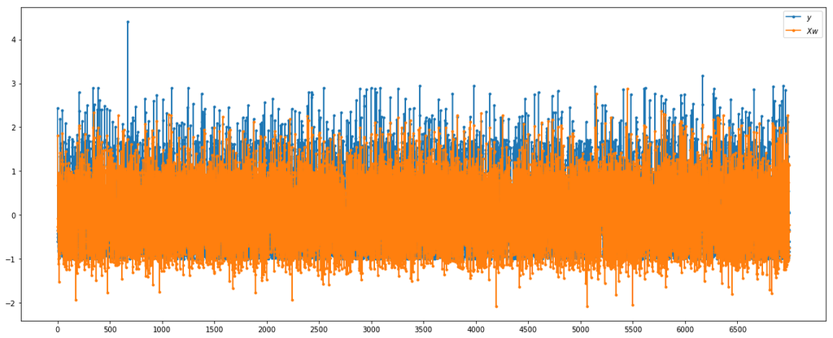

```python
plt.clf
plt.figure(figsize = (20,8))
plt.plot(y_test.values, '.-' )
plt.plot(X_test.dot(w).values, '.-' )
plt.xticks(np.arange(0, X_test.shape[0], step=500))
plt.legend(('$y$', '$X w$'));
```

We can now estimate the relative prediction error.

```python
E_LR = np.linalg.norm(X_test.dot(w)-y_test) / np.linalg.norm(y_test)
print(( 'Relative prediction error: ' + str(E_LR) ) );
```

```
Relative prediction error: 0.5112455300416369
```

### Scikit learn results

We compare these results with those obtained by using *LinearRegression()* function from **scikit-learn** library.

The relative prediction errors appear to be equal. Plus, the performance of the estimator on the test data is very similar to the performance on training data.

```python
regr = linear_model.LinearRegression()
regr.fit(X_train, y_train)
y_pred_lr = regr.predict(X_test)
E_LR_scikit = np.linalg.norm(y_pred_lr-y_test) / np.linalg.norm(y_test)
print('Relative prediction error: %.3f' % E_LR_scikit)
print('Mean squared error: %.2f' % mean_squared_error(y_test, y_pred_lr))
print('Train score : %.3f' % regr.score(X_train, y_train))
print('Test score : %.3f' % regr.score(X_test, y_test))
```

```
Relative prediction error: 0.511
Mean squared error: 0.27
Train score : 0.736
Test score : 0.739
```

## Regularization using Ridge regression

### Method seen in class

Regularization is obtained by introducing a penalty. It is often called ridge regression, and is defined as $$ \min_{w} \left\lVert{Xw-y}\right\rVert^2 + \lambda \left\lVert{w}\right\rVert^2 $$ where $\lambda>0$ is the regularization parameter.

The solution is given using the following equivalent formula $$ w = (X^\top X + \lambda \text{Id}_p )^{-1} X^\top y, $$ $$ w = X^\top ( XX^\top + \lambda \text{Id}_n)^{-1} y, $$

When $p<n$ (which is the case here), the first formula should be prefered.

Results below confirm the equivalence between both formulas.

```python
Lambda = .2*np.linalg.norm(X_train)**2;
w = np.linalg.solve( X_train.transpose().dot(X_train) + Lambda*np.eye(p-1), X_train.transpose().dot(y_train) ) #ridge estimator
u = np.linalg.solve( X_train.dot(X_train.transpose()) + Lambda*np.eye(X_train.shape[0]), y_train )
w1 = X_train.transpose().dot( u )
print( ('Error (should be 0): ' + str( np.linalg.norm(w-w1)/np.linalg.norm(w) ) ) )
```

```
Error (should be 0): 2.4424701420725577e-15
```

We display the evolution of the test error $E$ as a function of $\lambda$. This plot also indicates the optimal $\lambda$ and the associated $E$.

For the optimal lambda, **the ridge model strangely resembles the basic linear model**. Thus, the relative prediction error is similar to the one obtained with the basic LR model. This could be due to multi-colinearity issue.

```
Ridge relative prediction error: 51.153%
Optimal Lambda: 0.000001
```

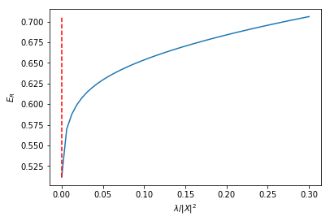

```python
q = 50
lmax = np.linalg.norm(X_train,2)**2
lambda_list = lmax*np.linspace(.3,1e-6,q)
W = np.zeros( (p-1,q) )
E_R = np.zeros( (q,1) )
for i in np.arange(0,q):
    Lambda = lambda_list[i]
    w = np.linalg.solve( X_train.transpose().dot(X_train) + Lambda*np.eye(p-1), X_train.transpose().dot(y_train) )
    W[:,i] = w.flatten() # bookkeeping
    E_R[i] = np.linalg.norm(X_test.dot(w)-y_test) / np.linalg.norm(y_test)
# find optimal lambda
i = E_R.argmin()
lambda0_R = lambda_list[i]
wRidge = W[:,i]
print('Ridge relative prediction error: %.3f' % (E_R.min()*100) + '%' )
print('Optimal Lambda: %.6f' % (lambda0_R/lmax))
# Display error evolution.
plt.clf
plt.figure(figsize = (20,8))
plt.plot(lambda_list/lmax, E_R)
plt.plot( [lambda0_R/lmax,lambda0_R/lmax], [E_R.min(), E_R.max()], 'r--')
plt.axis('tight')
plt.xlabel('$\lambda/|X|^2$')
plt.ylabel('$E_R$')
```

We take a look at the magnitude of the coefficients obtained for the optimal $\lambda\$. We see that only 3 features coefficients are very close to 0 after the ridge regularization process.

```
Number of features close to zero : 3
```

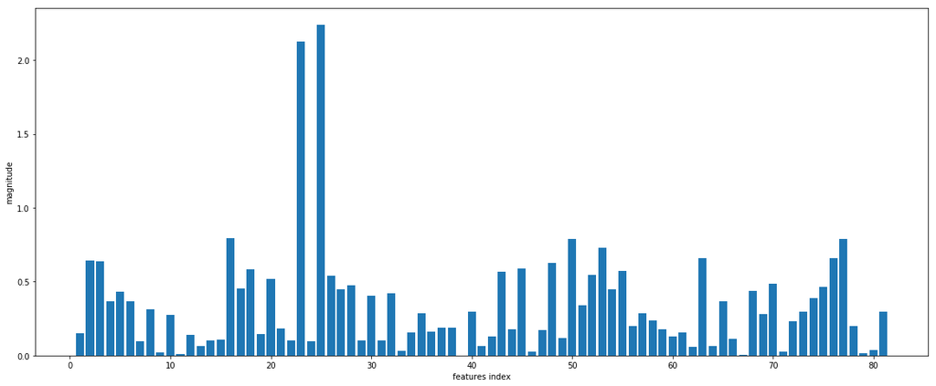

```python
plt.figure(figsize = (20,8))
plt.bar(np.arange(1,p),abs(wRidge))
print('Number of features close to zero : ' + str(sum((abs(wRidge) < 0.01))))
plt.xlabel('features index')
plt.ylabel('magnitude')
```

We confirm this conclusion by looking at the solution path of each feature.

```
No handles with labels found to put in legend.
```

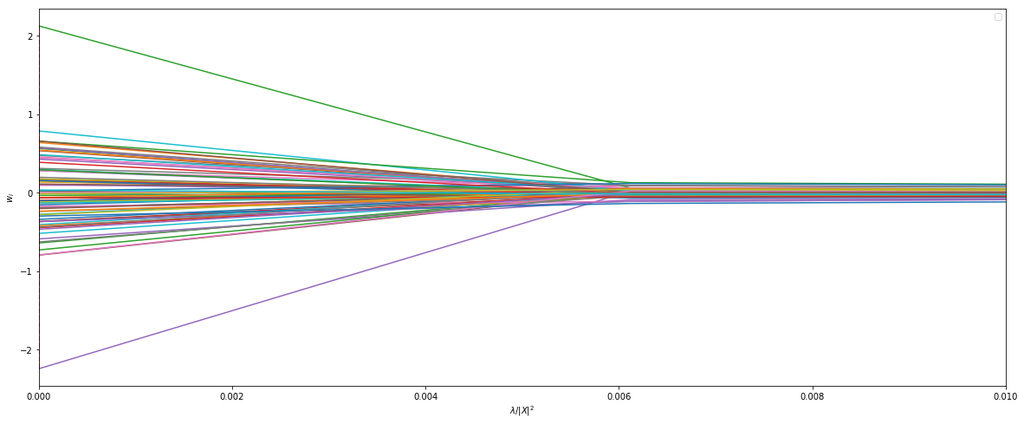

```python
plt.clf
plt.figure(figsize = (20,8))
for i in np.arange(0,p-1):
    plt.plot(lambda_list/lmax, W[i,:])
plt.plot([lambda0_R/lmax,lambda0_R/lmax], [W.flatten().min(), W.flatten().max()], 'r--')
plt.axis('tight')
plt.xlabel('$\lambda/|X|^2$')
plt.ylabel('$w_i$')
plt.xlim(0,0.01)
plt.legend()
```

### Scikit learn results

We use *Ridge()* and *RidgeCV()* functions from **scikitlearn** library in order to compare the results and metrics for different $\lambda$ values.

Here, we calculate the optimal $\lambda$ using *RidgeCV* function. Its value is equal to the one obtained with the custom method seen in class. Same observation for the relative prediction error.

When $\lambda$ is increasing, ridge regression shrinks the coefficients. Howether, an underfitting issue appears as train and test scores decrease.

```python
#ridge optimal lambda estimated by CV, folds nb = 5
Ridgeopt = RidgeCV(alphas=[0.000001, 0.00001, 0.0001, 0.0003, 0.0006, 0.001, 0.003, 0.006, 0.01, 0.03, 0.06, 0.1, 0.3, 0.6, 1], cv=5, normalize = True)
Ridgeopt.fit(X_train,y_train)
y_pred_Ridgeopt = Ridgeopt.predict(X_test)
E_Ridge_opt_scikit = np.linalg.norm(y_pred_Ridgeopt-y_test) / np.linalg.norm(y_test)
print('Optimal lambda: ' + str(Ridgeopt.alpha_))
print('Relative prediction error: %.3f' % E_Ridge_opt_scikit)
print('Mean squared error: %.2f' % mean_squared_error(y_test, y_pred_Ridgeopt))
print('Train score : %.3f' % Ridgeopt.score(X_train, y_train))
print('Test score : %.3f' % Ridgeopt.score(X_test, y_test))
```

```
Optimal lambda: 1e-06
Relative prediction error: 0.511
Mean squared error: 0.27
Train score : 0.736
Test score : 0.739
```

```python
# ridge lambda = 0.01
Ridge001 = Ridge(alpha=0.01, normalize = True)
Ridge001.fit(X_train,y_train)
y_pred_Ridge001 = Ridge001.predict(X_test)
E_Ridge_001_scikit = np.linalg.norm(y_pred_Ridge001-y_test) / np.linalg.norm(y_test)
print('Relative prediction error: %.3f' % E_Ridge_001_scikit)
print('Mean squared error: %.2f' % mean_squared_error(y_test, y_pred_Ridge001))
print('Train score : %.3f' % Ridge001.score(X_train, y_train))
print('Test score : %.3f' % Ridge001.score(X_test, y_test))
```

```
Relative prediction error: 0.528
Mean squared error: 0.28
Train score : 0.718
Test score : 0.721
```

```python
# ridge lambda = 0.1
Ridge01 = Ridge(alpha=0.1, normalize = True)
Ridge01.fit(X_train,y_train)
y_pred_Ridge01 = Ridge01.predict(X_test)
E_Ridge_01_scikit = np.linalg.norm(y_pred_Ridge01-y_test) / np.linalg.norm(y_test)
print('Relative prediction error: %.3f' % E_Ridge_01_scikit)
print('Mean squared error: %.2f' % mean_squared_error(y_test, y_pred_Ridge01))
print('Train score : %.3f' % Ridge01.score(X_train, y_train))
print('Test score : %.3f' % Ridge01.score(X_test, y_test))
```

```
Relative prediction error: 0.556
Mean squared error: 0.32
Train score : 0.687
Test score : 0.691
```

```python
# ridge lambda = 10
Ridge10 = Ridge(alpha=10, normalize = True)
Ridge10.fit(X_train,y_train)
y_pred_Ridge10 = Ridge10.predict(X_test)
E_Ridge_10_scikit = np.linalg.norm(y_pred_Ridge10-y_test) / np.linalg.norm(y_test)
print('Relative prediction error: %.3f' % E_Ridge_10_scikit)
print('Mean squared error: %.2f' % mean_squared_error(y_test, y_pred_Ridge10))
print('Variance score: %.2f' % r2_score(y_test, y_pred_Ridge10)) # Explained variance score: 1 is perfect prediction
print('Train score : %.3f' % Ridge10.score(X_train, y_train))
print('Test score : %.3f' % Ridge10.score(X_test, y_test))
```

```
Relative prediction error: 0.709
Mean squared error: 0.51
Variance score: 0.50
Train score : 0.495
Test score : 0.497
```

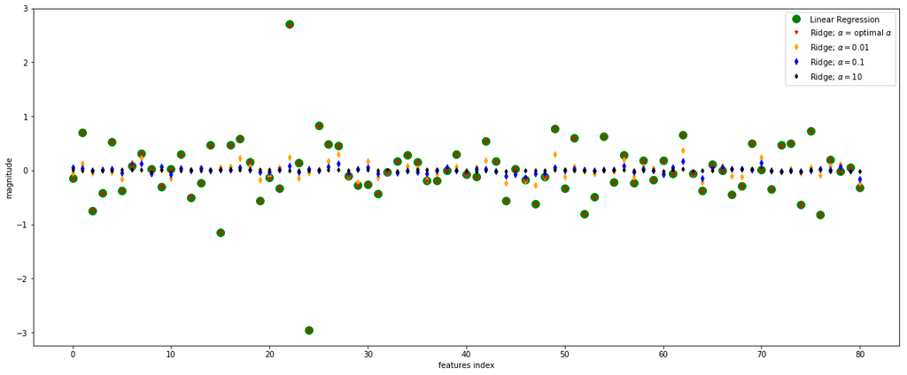

```python
plt.figure(figsize = (20,8))
plt.plot(regr.coef_,alpha=1,linestyle='none',marker='o',markersize=10,color='green',label='Linear Regression')
plt.plot(Ridgeopt.coef_,alpha=1,linestyle='none',marker='*',markersize=5,color='red',label=r'Ridge; $\alpha$ = optimal $\alpha$',zorder=7)
plt.plot(Ridge001.coef_,alpha=1,linestyle='none',marker='d',markersize=5,color='orange',label=r'Ridge; $\alpha = 0.01$')
plt.plot(Ridge01.coef_,alpha=1,linestyle='none',marker='d',markersize=5,color='blue',label=r'Ridge; $\alpha = 0.1$')
plt.plot(Ridge10.coef_,alpha=1,linestyle='none',marker='d',markersize=4,color='black',label=r'Ridge; $\alpha = 10$')
plt.legend()
plt.xlabel('features index')
plt.ylabel('magnitude')
```